# matplotlib.axes.Axes.set_aspect

**Axes.set_aspect(*aspect*, *adjustable=None*, *anchor=None*, *share=False*)[[source]](https://github.com/matplotlib/matplotlib/blob/v3.7.1/lib/matplotlib/axes/_base.py#L1616-L1686)**

Set the aspect ratio of the axes scaling, i.e. y/x-scale.

**Parameters:**

**aspect**{'auto', 'equal'} or float**

Possible values:

- 'auto': fill the position rectangle with data.
- 'equal': same as `aspect=1`, i.e. same scaling for x and y.
- *float*: The displayed size of 1 unit in y-data coordinates will be *aspect* times the displayed size of 1 unit in x-data coordinates; e.g. for `aspect=2` a square in data coordinates will be rendered with a height of twice its width.

**adjustable**None or {'box', 'datalim'}, optional**

If not `None`, this defines which parameter will be adjusted to meet the required aspect. See `set_adjustable` for further details.

**anchor**None or str or (float, float), optional**

If not `None`, this defines where the Axes will be drawn if there is extra space due to aspect constraints. The most common way to specify the anchor are abbreviations of cardinal directions:

| value | description |
| --- | --- |
| 'C' | centered |
| 'SW' | lower left corner |
| 'S' | middle of bottom edge |
| 'SE' | lower right corner |
| etc. |  |

See `set_anchor` for further details.

**share**bool, default: False**

If `True`, apply the settings to all shared Axes.

See also

**`matplotlib.axes.Axes.set_adjustable`**

Set how the Axes adjusts to achieve the required aspect ratio.

**`matplotlib.axes.Axes.set_anchor`**

Set the position in case of extra space.

## Examples using `matplotlib.axes.Axes.set_aspect`

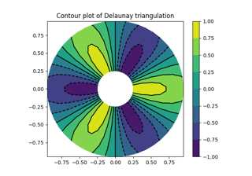

[Tricontour Demo](https://matplotlib.org/stable/gallery/images_contours_and_fields/tricontour_demo.html#sphx-glr-gallery-images-contours-and-fields-tricontour-demo-py)

Tricontour Demo

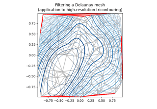

[Tricontour Smooth Delaunay](https://matplotlib.org/stable/gallery/images_contours_and_fields/tricontour_smooth_delaunay.html#sphx-glr-gallery-images-contours-and-fields-tricontour-smooth-delaunay-py)

Tricontour Smooth Delaunay

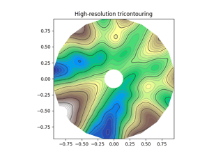

[Tricontour Smooth User](https://matplotlib.org/stable/gallery/images_contours_and_fields/tricontour_smooth_user.html#sphx-glr-gallery-images-contours-and-fields-tricontour-smooth-user-py)

Tricontour Smooth User

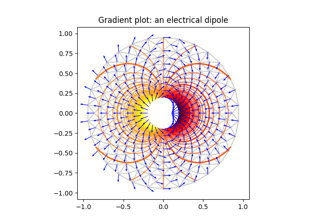

[Trigradient Demo](https://matplotlib.org/stable/gallery/images_contours_and_fields/trigradient_demo.html#sphx-glr-gallery-images-contours-and-fields-trigradient-demo-py)

Trigradient Demo

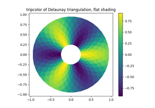

[Tripcolor Demo](https://matplotlib.org/stable/gallery/images_contours_and_fields/tripcolor_demo.html#sphx-glr-gallery-images-contours-and-fields-tripcolor-demo-py)

Tripcolor Demo

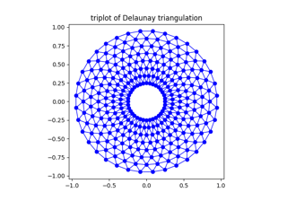

[Triplot Demo](https://matplotlib.org/stable/gallery/images_contours_and_fields/triplot_demo.html#sphx-glr-gallery-images-contours-and-fields-triplot-demo-py)

Triplot Demo

[figure not shown]

[Axes box aspect](https://matplotlib.org/stable/gallery/subplots_axes_and_figures/axes_box_aspect.html#sphx-glr-gallery-subplots-axes-and-figures-axes-box-aspect-py)

Axes box aspect

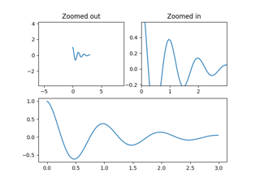

[Controlling view limits using margins and sticky_edges](https://matplotlib.org/stable/gallery/subplots_axes_and_figures/axes_margins.html#sphx-glr-gallery-subplots-axes-and-figures-axes-margins-py)

Controlling view limits using margins and sticky_edges

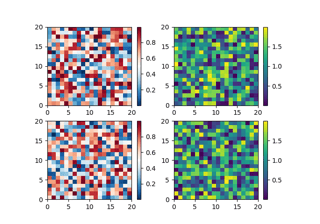

[Placing Colorbars](https://matplotlib.org/stable/gallery/subplots_axes_and_figures/colorbar_placement.html#sphx-glr-gallery-subplots-axes-and-figures-colorbar-placement-py)

Placing Colorbars

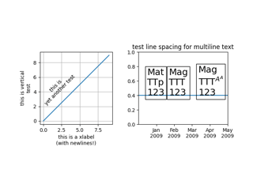

[Multiline](https://matplotlib.org/stable/gallery/text_labels_and_annotations/multiline.html#sphx-glr-gallery-text-labels-and-annotations-multiline-py)

Multiline

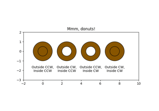

[Mmh Donuts!!!](https://matplotlib.org/stable/gallery/shapes_and_collections/donut.html#sphx-glr-gallery-shapes-and-collections-donut-py)

Mmh Donuts!!!

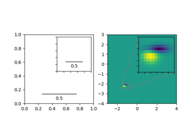

[Inset locator demo 2](https://matplotlib.org/stable/gallery/axes_grid1/inset_locator_demo2.html#sphx-glr-gallery-axes-grid1-inset-locator-demo2-py)

Inset locator demo 2

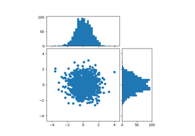

[Scatter Histogram (Locatable Axes)](https://matplotlib.org/stable/gallery/axes_grid1/scatter_hist_locatable_axes.html#sphx-glr-gallery-axes-grid1-scatter-hist-locatable-axes-py)

Scatter Histogram (Locatable Axes)

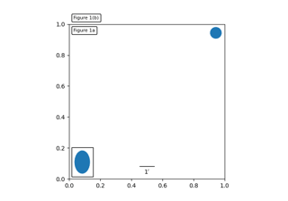

[Simple Anchored Artists](https://matplotlib.org/stable/gallery/axes_grid1/simple_anchored_artists.html#sphx-glr-gallery-axes-grid1-simple-anchored-artists-py)

Simple Anchored Artists

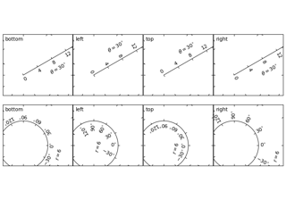

[axis_direction demo](https://matplotlib.org/stable/gallery/axisartist/demo_axis_direction.html#sphx-glr-gallery-axisartist-demo-axis-direction-py)

axis_direction demo

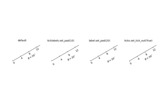

[Simple Axis Pad](https://matplotlib.org/stable/gallery/axisartist/simple_axis_pad.html#sphx-glr-gallery-axisartist-simple-axis-pad-py)

Simple Axis Pad

[figure not shown]

[The double pendulum problem](https://matplotlib.org/stable/gallery/animation/double_pendulum.html#sphx-glr-gallery-animation-double-pendulum-py)

The double pendulum problem

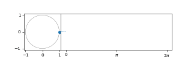

[Multiple axes animation](https://matplotlib.org/stable/gallery/animation/multiple_axes.html#sphx-glr-gallery-animation-multiple-axes-py)

Multiple axes animation

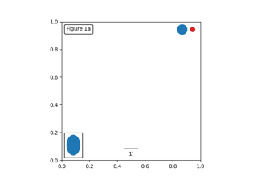

[Anchored Artists](https://matplotlib.org/stable/gallery/misc/anchored_artists.html#sphx-glr-gallery-misc-anchored-artists-py)

Anchored Artists

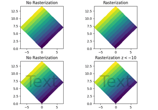

[Rasterization for vector graphics](https://matplotlib.org/stable/gallery/misc/rasterization_demo.html#sphx-glr-gallery-misc-rasterization-demo-py)

Rasterization for vector graphics

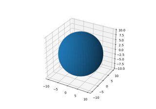

[3D surface (solid color)](https://matplotlib.org/stable/gallery/mplot3d/surface3d_2.html#sphx-glr-gallery-mplot3d-surface3d-2-py)

3D surface (solid color)

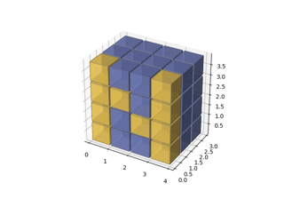

[3D voxel plot of the NumPy logo](https://matplotlib.org/stable/gallery/mplot3d/voxels_numpy_logo.html#sphx-glr-gallery-mplot3d-voxels-numpy-logo-py)

3D voxel plot of the NumPy logo

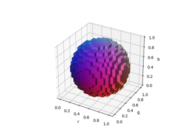

[3D voxel / volumetric plot with RGB colors](https://matplotlib.org/stable/gallery/mplot3d/voxels_rgb.html#sphx-glr-gallery-mplot3d-voxels-rgb-py)

3D voxel / volumetric plot with RGB colors

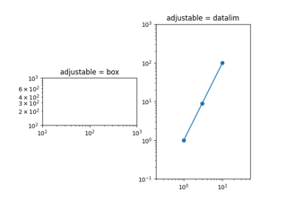

[Loglog Aspect](https://matplotlib.org/stable/gallery/scales/aspect_loglog.html#sphx-glr-gallery-scales-aspect-loglog-py)

Loglog Aspect

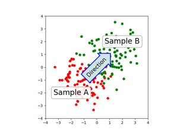

[Annotate Text Arrow](https://matplotlib.org/stable/gallery/userdemo/annotate_text_arrow.html#sphx-glr-gallery-userdemo-annotate-text-arrow-py)

Annotate Text Arrow

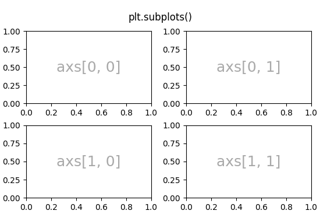

[Arranging multiple Axes in a Figure](https://matplotlib.org/stable/tutorials/intermediate/arranging_axes.html#sphx-glr-tutorials-intermediate-arranging-axes-py)

Arranging multiple Axes in a Figure

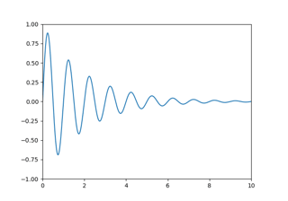

[Transformations Tutorial](https://matplotlib.org/stable/tutorials/advanced/transforms_tutorial.html#sphx-glr-tutorials-advanced-transforms-tutorial-py)

Transformations Tutorial

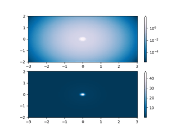

[Colormap Normalization](https://matplotlib.org/stable/tutorials/colors/colormapnorms.html#sphx-glr-tutorials-colors-colormapnorms-py)

Colormap Normalization

© 2012–2023 Matplotlib Development Team. All rights reserved.  
Licensed under the Matplotlib License Agreement.  
https://matplotlib.org/stable/api/_as_gen/matplotlib.axes.Axes.set_aspect.html